# Part II - Analysis of Effects of Loan Characteristics on Loan Amounts

## by Geoffrey Mosongo

## Investigation Overview

In this anlaysis, various characteristics of loans that could be used to predict their borrower APR are examined. Characteristics of interest include; the original loan amount, the borrower's Prosper rating, loan term, borrower's stated monthly income and house ownership.

## Dataset Overview

There are 113,937 loans in the dataset with 81 characteristics. Most variables are numeric and categorical in nature. The characteristics included original loan amount, borrower's Prosper rating, loan term, borrower's stated monthly income, as well as many other features such as borrower's employment status, debt to income ratio, current loan status etc.

## Loan Origination Year

When Prosper started business in 2005 a few loans were issued. According to Wikipedia, they stopped their business between Nov 2008 - July 2009 explaining why the number of loans given out decreased during this period.

The number of new loans increased from 2010 with 2013 recoring the highest number.

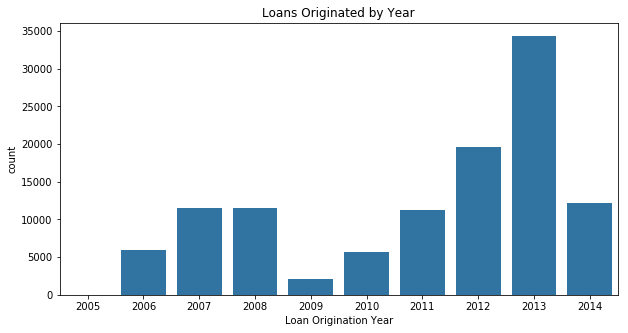

## Enumerating Numerical Data

- The correlation coefficient of borrower APR and loan original amount is -0.323, implying that the more the loan amount, the lower the APR.
- The loan original amount is positively correlated with the stated monthly income, indicating that borrowers who earn more per month contend with more loan amounts.

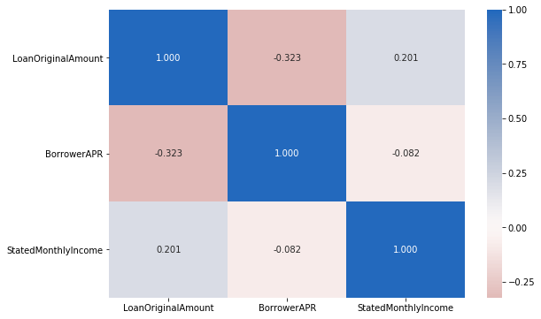

## Does APR and Loan Original Amount Determine Interest Rates?

- Higher loan amounts attract lower interst rates but with higher monthly installments

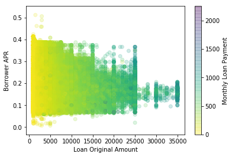